# 第三篇 R统计分析-示例

2017-06-18

## 大纲

- **线性回归**
- **逻辑回归**
- **协同过滤**

## 线性回归

- 数据描述(pce个人消费支出,psavert个人储蓄率)

```r
data(economics,package="ggplot2"); tail(economics,2)  #help(economics)
```

```
##           date     pce    pop psavert uempmed unemploy
## 573 2015-03-01 12161.5 320707     5.2    12.2     8575
## 574 2015-04-01 12158.9 320887     5.6    11.7     8549
```

```r
x<-economics$psavert
y<-economics$pce
summary(cbind(x,y))
```

```
##        x                y
##  Min.   : 1.900   Min.   :  507.4
##  1st Qu.: 5.500   1st Qu.: 1582.2
##  Median : 7.700   Median : 3953.6
##  Mean   : 7.937   Mean   : 4843.5
##  3rd Qu.:10.500   3rd Qu.: 7667.3
##  Max.   :17.000   Max.   :12161.5
```

## 线性回归

- 负相关

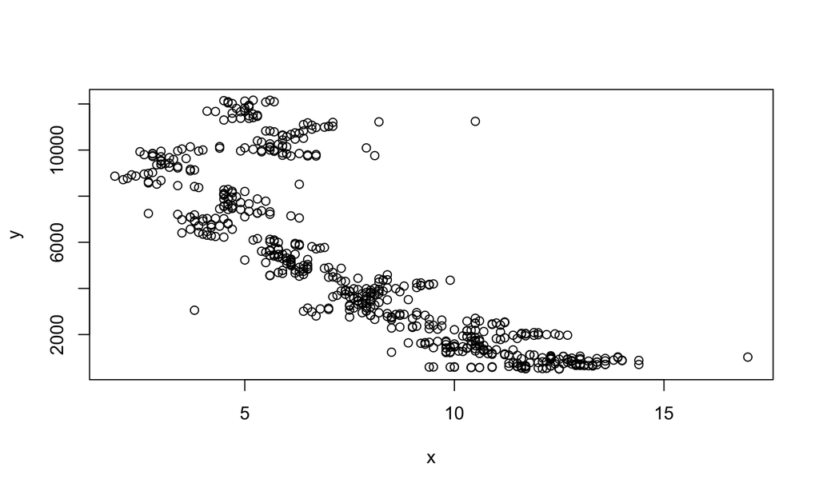

```r
plot(y~x)
```

## 线性回归

- 参数估计初始化

```r
x <- cbind(1,x)
n <- nrow(x)
#待估参数
aa <- c(0,-10)
aa2<- c(0,0)
#初始损失函数值
cost <- sum(((x%*%aa)- y)^2)/(2*n)

#学习率
rr <- 0.01
#迭代次数
nt <- 1000
```

## 线性回归

- 参数估计梯度下降

```r
for(i in 1:nt)
{
  aa[1] <- aa[1] - rr * (1/n) * sum(((x%*%aa)- y))
  aa[2] <- aa[2] - rr * (1/n) * sum(((x%*%aa)- y)*x[,2])
}
#估计参数
aa
```

```
## [1] 9192.9325 -602.8978
```

```r
#预测结果
yp<-x%*%aa
head(cbind(x,y,yp))
```

```
##           x     y
## [1,] 1 12.5 507.4 1656.710
## [2,] 1 12.5 510.5 1656.710
## [3,] 1 11.7 516.3 2139.028
## [4,] 1 12.5 512.9 1656.710
## [5,] 1 12.5 518.1 1656.710
## [6,] 1 12.1 525.8 1897.869
```

## 线性回归

- 梯度下降预测结果

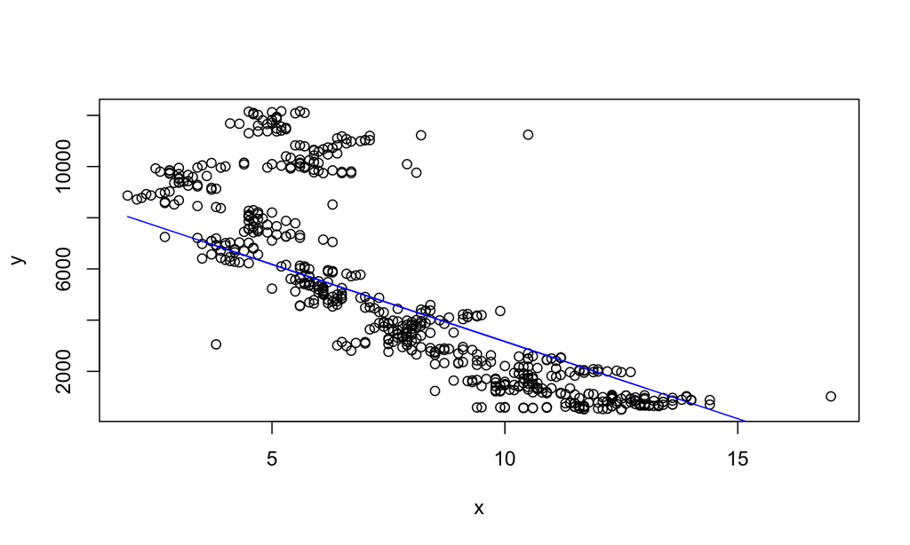

```r
x<-x[,2]
plot(y~x)
lines(yp~x,col='blue')
```

## 线性回归

- lm预测结果

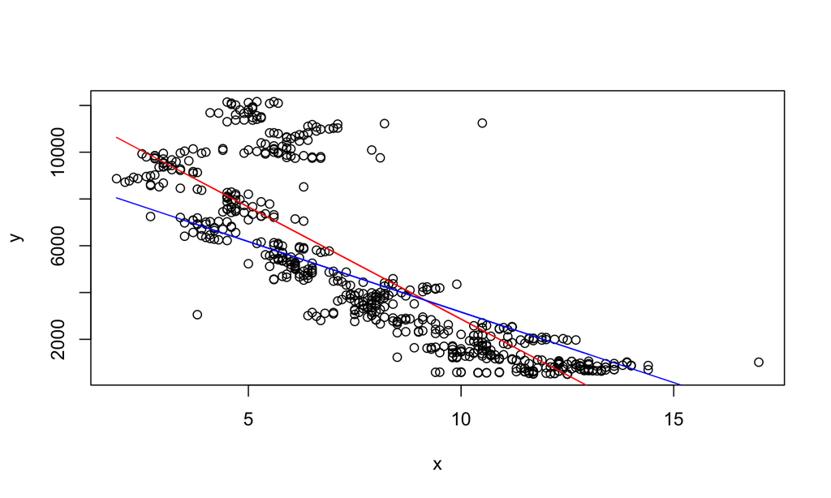

```r
md<-lm(y~x,data=data.frame(cbind(x,y)))
plot(y~x)
lines(md$fitted.values~x,col='red');lines(yp~x,col='blue')
```

## 线性回归

- 公式推导

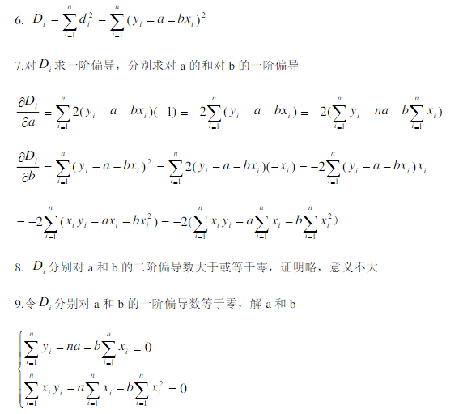

## 线性回归

- 公式计算

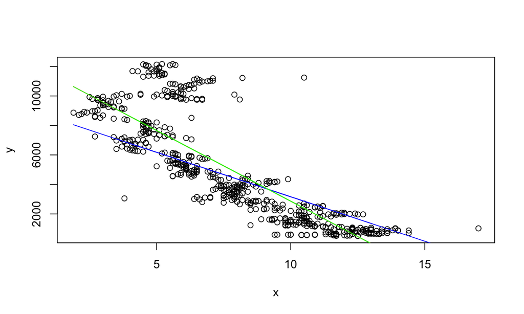

```r
aa2[2]=(n*sum(x*y)-sum(x)*sum(y))/(n*sum(x^2)-(sum(x))^2)
aa2[1]=mean(y)-aa2[2]*mean(x)
yp2=cbind(1,x)%*%aa2
plot(y~x);lines(md$fitted.values~x,col='red');lines(yp~x,col='blue');lines(yp2~x,col='green')
```

## 线性回归

- 三种方法的估计比较

```r
#梯度下降
aa
```

```
## [1] 9192.9325 -602.8978
```

```r
#公式
aa2
```

```
## [1] 12454.2309  -958.9414
```

```r
#lm
md$coefficients
```

```
## (Intercept)           x
##  12454.2309   -958.9414
```

## 逻辑回归

- 数据描述

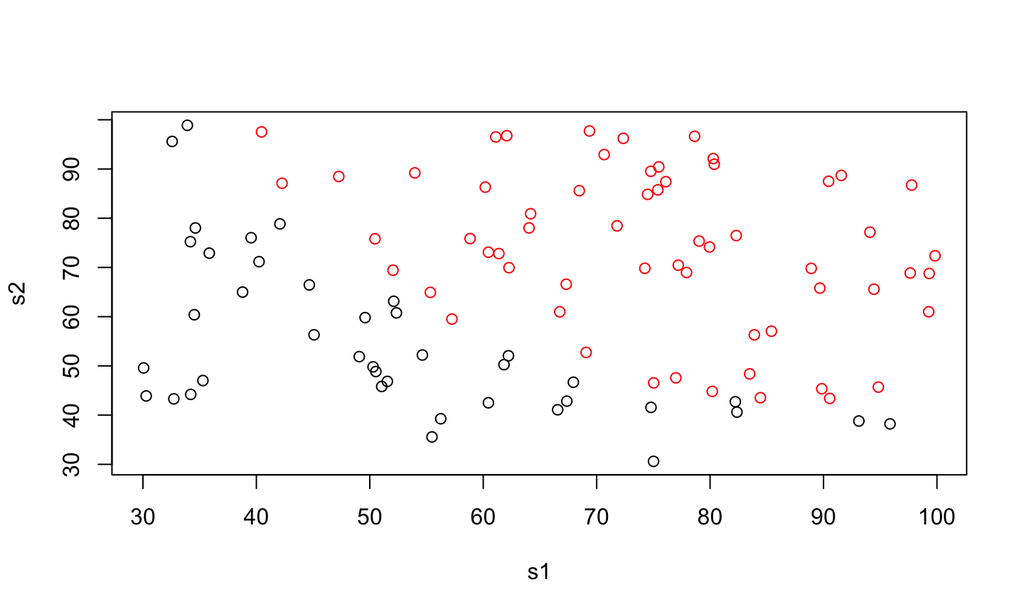

```r
df <- read.csv("../data/admission-data.csv")
names(df)<-c('s1','s2','label')
plot(s2~s1,col=as.factor(label),data=df)
```

## 逻辑回归

- 公式推导

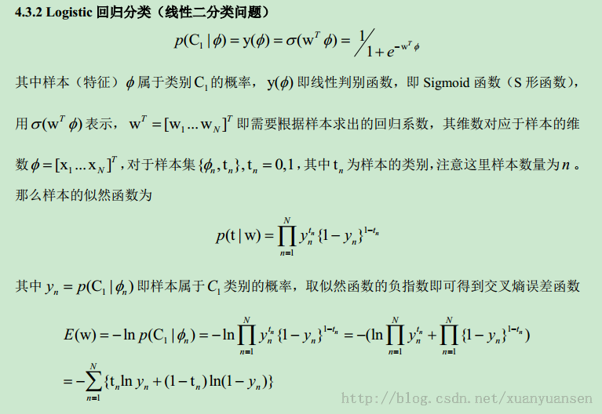

## 逻辑回归

- 公式推导

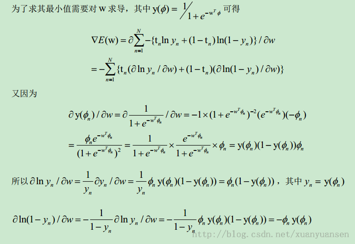

## 逻辑回归

- 初始化

```r
x <- as.matrix(df[,c(1,2)])
x <- cbind(1,x)
y <- as.matrix(df$label)

mysig <- function(z)
{
  g <- 1/(1+exp(-z))
  return(g)
}
```

## 逻辑回归

- 损失函数

```r
mycost <- function(aa)
{
n <- nrow(x)
g <- mysig(x%*%aa)
cost <- (1/n)*sum((-y*log(g)) - ((1-y)*log(1-g)))
return(cost)
}

aa <- rep(0,ncol(x))
mycost(aa)
```

```
## [1] 0.6931472
```

## 逻辑回归

- 参数估计

```r
aaoptim <- optim(par=aa,fn=mycost)
aa <- aaoptim$par  ;aa
```

```
## [1] -25.1647048   0.2062524   0.2015046
```

```r
yp <- mysig(x%*%aa)
df$yp=ifelse(yp>=0.5,1,0)
head(df)
```

```
##         s1       s2 label yp
## 1 34.62366 78.02469     0  0
## 2 30.28671 43.89500     0  0
## 3 35.84741 72.90220     0  0
## 4 60.18260 86.30855     1  1
## 5 79.03274 75.34438     1  1
## 6 45.08328 56.31637     0  0
```

## 逻辑回归

- 预测结果

```r
tb <- with(df, table(label, yp));tb
```

```
##      yp
## label  0  1
##     0 34  6
##     1  5 55
```

```r
prop.table(tb)
```

```
##      yp
## label    0    1
##     0 0.34 0.06
##     1 0.05 0.55
```

```r
#glm,自行比较
```

## 协同过滤

- 原理示意

[figure not shown]

## 协同过滤

- 代码示例  
  for(i in 1:nrow(holder))  
  {  
  for(j in 1:ncol(holder))  
  {  
  user <- rownames(holder)[i]  
  product <- colnames(holder)[j]  
  if(as.integer(data.germany[data.germany$user==user,product]) == 1)  
  {  
  holder[i,j]<-""  
  } else {  
  topN<-((head(n=11,(data.germany.ibs.similarity[order(data.germany.ibs.similarity[,product],decreasing=TRUE),][product]))))  
  topN.names <- as.character(rownames(topN))  
  topN.similarities <- as.numeric(topN[,1])  
  topN.similarities<-topN.similarities[-1]  
  topN.names<-topN.names[-1]  
  topN.purchases<- data.germany[,c("user",topN.names)]  
  topN.userPurchases<-topN.purchases[topN.purchases$user==user,]  
  topN.userPurchases <- as.numeric(topN.userPurchases[!(names(topN.userPurchases) %in% c("user"))])  
  holder[i,j]<-getScore(similarities=topN.similarities,history=topN.userPurchases)  
  } # close else statement  
  } # end product for loop  
  } # end user for loop

## 参考

[1]: Amar Gondaliya,2013,Linear Regression with R : step by step implementation  
[2]: Amar Gondaliya,2013,Logistic Regression with R: step by step implementation  
[3]: Salem,2014,Collaborative Filtering with R